# Respirometry - assemble final values from LoLin outputs

Samuel Gurr

October 29, 2018

## Exposure 1 (10-day OA): SMR and respirometry

plot all automated outputs to the “reference”

Reference = each value saved individually based on visual criteria of LoLin plots defatult at alpha 0.2, no truncation, and Lpc

Automated ouputs = looped the LoLin function for nine pairs of constants at alpha = 0.2, 0.4 and 0.6 for three levels of truncation of 30 minute trials (no truncation, 10-20mins, 10-25 mins) - aways target Lpc.

Below you can see that alpha 0.2 and alpha 0.4 with no truncation are strongly correlated to the reference

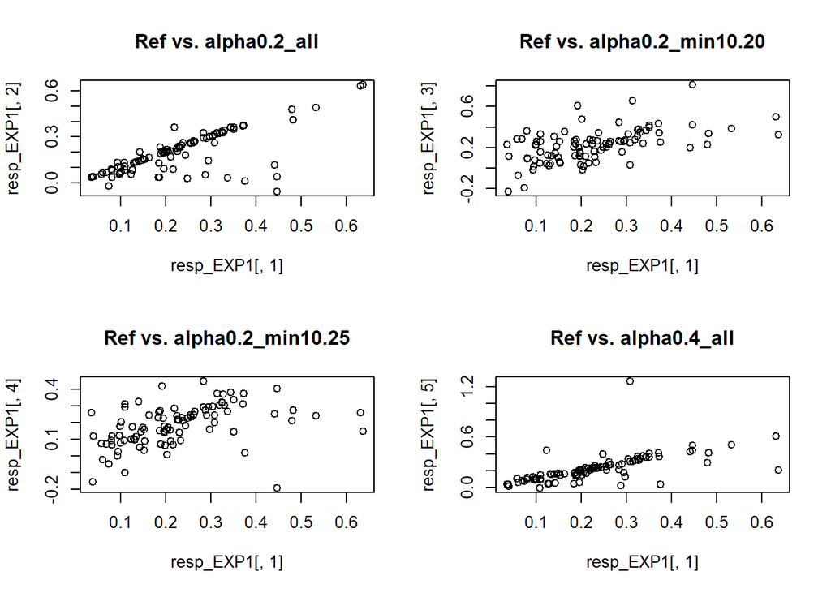

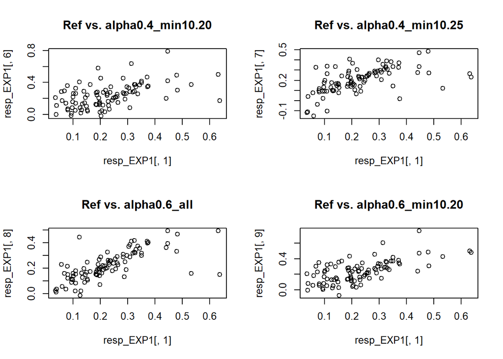

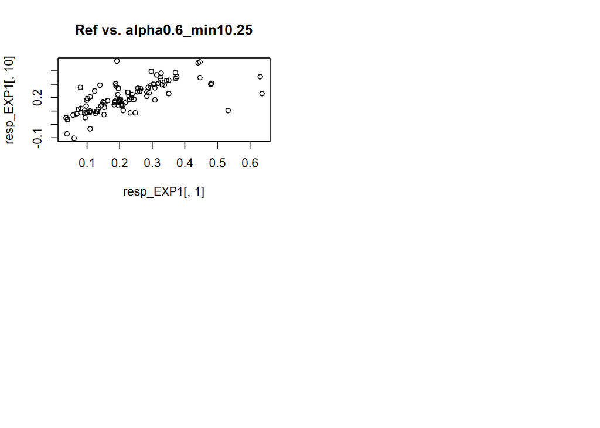

## Create an final dataset (LOESS curve, linear regression, merge data)

1. Determine that alpha = 0.4 no truncation has LEAST number of points outside of the LOESS curve to the reference
- ID points outside of the LOESS CI interval

RESULT: 18 points outside of loess

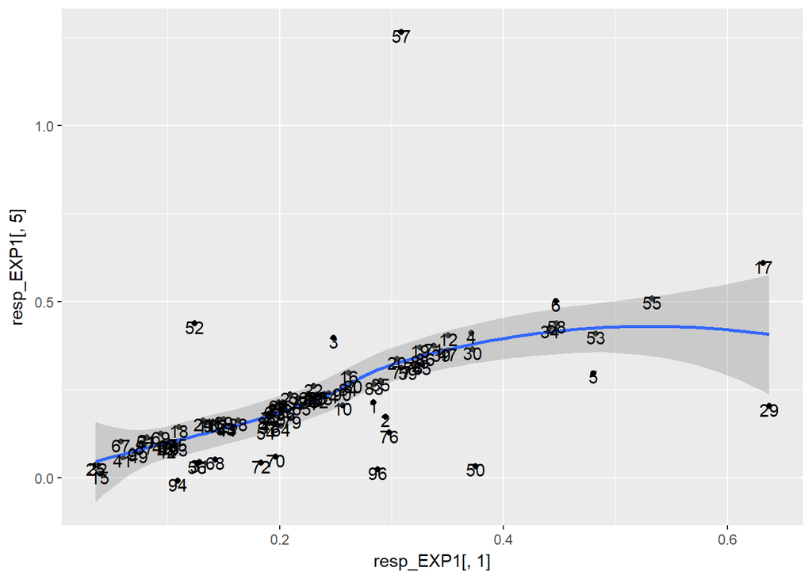

2. call these 18 values for each column (automated LoLin ouput) into a new dataframe

Run linear regressions to the reference

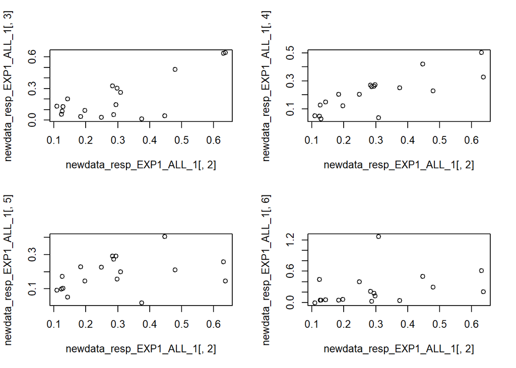

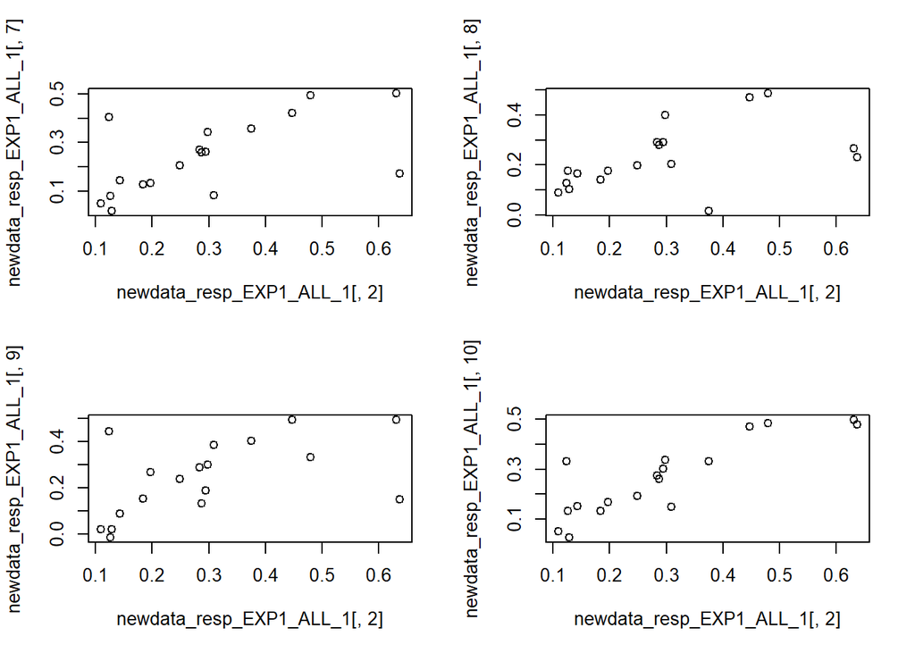

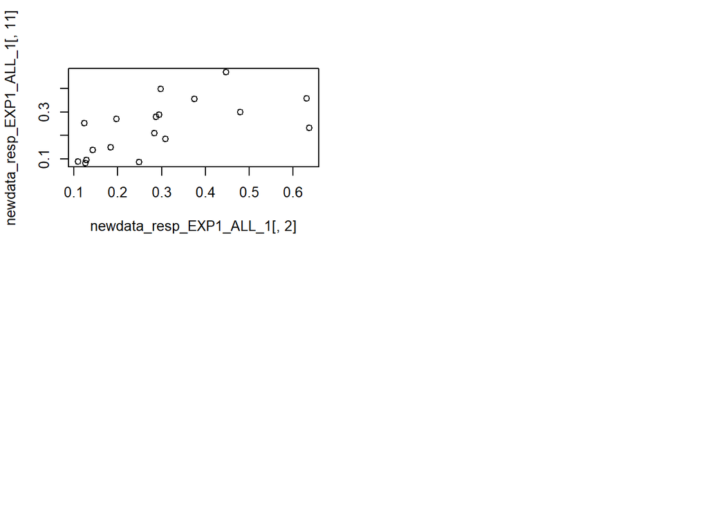

3. Merge with alpha 0.4 no truncation to create final column. Plot with reference.

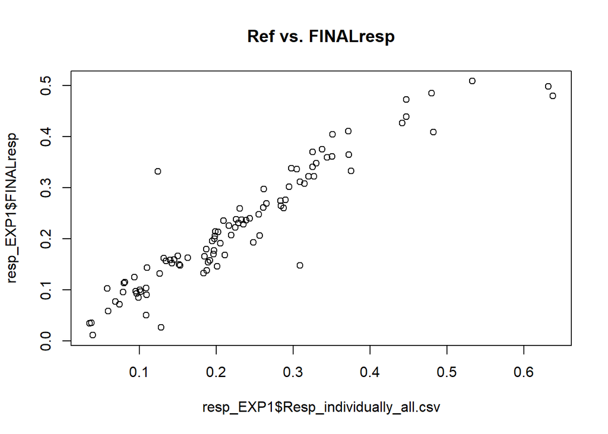

```
##
## Call:
## lm(formula = resp_EXP1[, 1] ~ resp_EXP1$FINALresp)
##
## Residuals:
##       Min        1Q    Median        3Q       Max
## -0.210095 -0.018657 -0.004914  0.011335  0.157757
##
## Coefficients:
##                     Estimate Std. Error t value Pr(>|t|)
## (Intercept)         0.008467   0.009524   0.889    0.376
## resp_EXP1$FINALresp 0.983298   0.037736  26.057   <2e-16 ***
## ---
## Signif. codes:  0 '***' 0.001 '**' 0.01 '*' 0.05 '.' 0.1 ' ' 1
##
## Residual standard error: 0.04358 on 94 degrees of freedom
## Multiple R-squared:  0.8784, Adjusted R-squared:  0.8771
## F-statistic:   679 on 1 and 94 DF,  p-value: < 2.2e-16
```

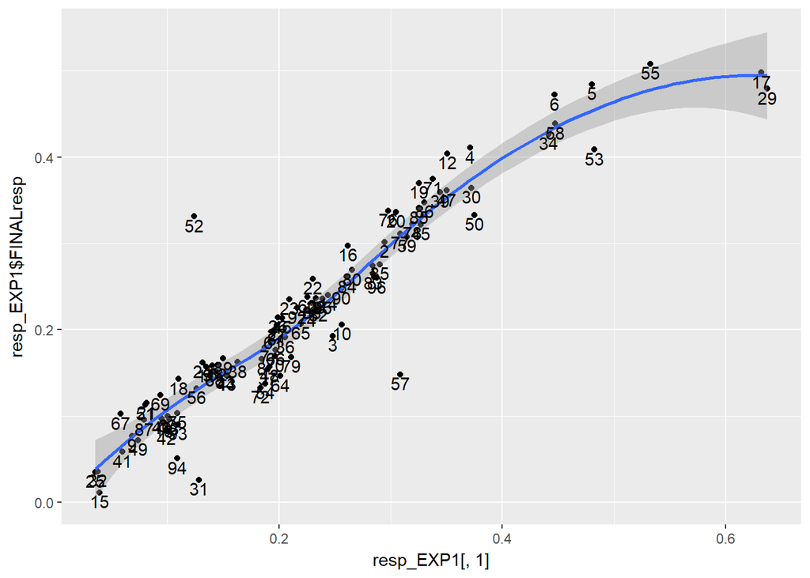